# Análise de Agrupamentos

## O que é clustering?

É uma **técnica estatística multivariada** para identificar agrupamentos dos dados de acordo com o grau de semelhança. Queremos achar um grupo de objetos, que são similares entre si e diferentes de outros grupos.

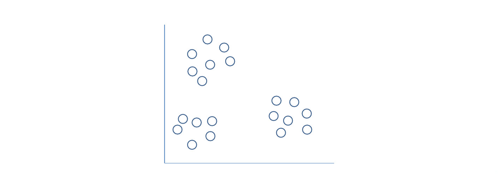

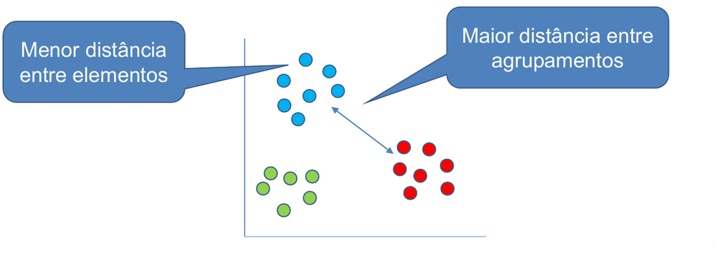

- O **objetivo** típico em clustering é descobrir os “agrupamentos naturais” presente nos dados.

## O que é clustering?

- Conjunto de dados **contendo** agrupamentos “naturais”:

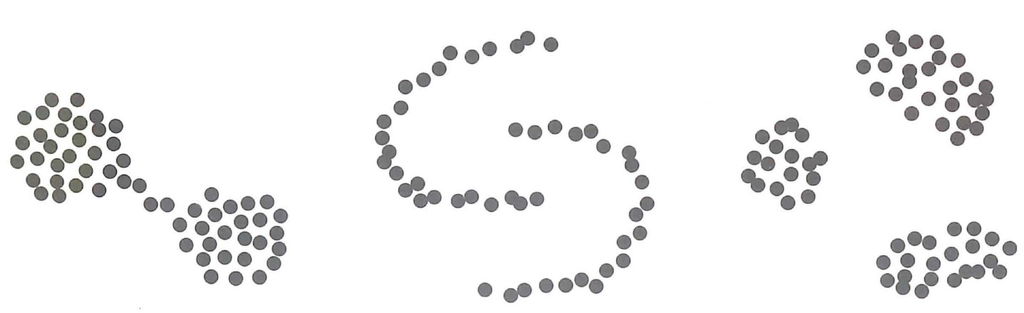

## O que é clustering?

- Conjunto de dados **sem** agrupamentos “naturais”:

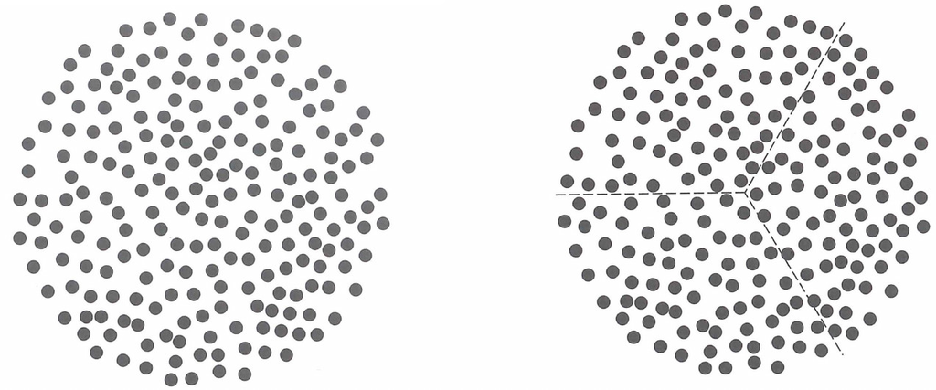

## Tendência de agrupamentos: “Faz sentido aplicar um algoritmo de clusterização nesses dados?”

### **Método estatístico:** Estatística de Hopkins

A **Estatística de Hopkins** é uma medida pré-clusterização muito usada para avaliar se um conjunto de dados apresenta tendência natural à formação de agrupamentos (clusters) ou se os pontos estão distribuídos de forma aproximadamente aleatória no espaço das variáveis.

## Tendência de agrupamentos: “Faz sentido aplicar um algoritmo de clusterização nesses dados?”

### **Método estatístico:** Estatística de Hopkins

- A ideia central é comparar distâncias:
  - Distâncias entre pontos reais do conjunto de dados
  - Distâncias entre pontos artificiais gerados aleatoriamente no mesmo espaço amostral
- Se os dados tiverem estrutura de clusters, os pontos reais tendem a estar mais próximos entre si do que pontos gerados aleatoriamente.

## Tendência de agrupamentos: “Faz sentido aplicar um algoritmo de clusterização nesses dados?”

### **Método estatístico:** Estatística de Hopkins

- Considerando um inteiro $m \ll n$, de pontos amostrados (normalizados), calcula-se a distância de cada ponto até o vizinho mais próximo, excluindo o próprio ponto

$$w_i
=
\min_{x_j \in X \setminus \{x_i\}}
d(x_i, x_j),
\qquad i = 1,\ldots,m$$

## Tendência de agrupamentos: “Faz sentido aplicar um algoritmo de clusterização nesses dados?”

### **Método estatístico:** Estatística de Hopkins

- Geram-se $m$ pontos artificiais $y_1, \ldots, y_m$, assumindo distribuição uniforme no hipercubo definido pelos limites dos dados e independência entre as dimensões. Para cada ponto artificial $j$, calcula-se a distância até o vizinho mais próximo no conjunto real.

$$u_i
=
\min_{x \in X}
d(y_i, x),
\qquad i = 1,\ldots,m$$

## Tendência de agrupamentos: “Faz sentido aplicar um algoritmo de clusterização nesses dados?”

### **Método estatístico:** Estatística de Hopkins

$$H = \dfrac{\sum \limits_{i=1}^m u_i}{\sum \limits_{i=1}^m u_i + \sum \limits_{i=1}^m w_i}$$

- $w_i$: distância do ponto real ao vizinho mais próximo
- $u_i$: distância do ponto artificial ao ponto real mais próximo

## Tendência de agrupamentos: “Faz sentido aplicar um algoritmo de clusterização nesses dados?”

### Interpretação da Estatística de Hopkins

Sob a hipótese de ausência de clusters (padrão de referência), espera-se que as distâncias $u_i$ e $w_i$ sejam, em média, comparáveis, o que leva a:
$$H \approx 0.5$$

Em termos práticos:

- $H \approx 0.5$: dados compatíveis com **padrão aleatório** (baixa tendência à clusterização);
- $H > 0.5$: evidência de **tendência à formação de clusters** (quanto mais próximo de 1, mais agregado);
- $H < 0.5$: padrão mais **regular ou espalhado** do que o aleatório.

## Tendência de agrupamentos: “Faz sentido aplicar um algoritmo de clusterização nesses dados?”

### Interpretação da Estatística de Hopkins

> **Observação:** como $H$ depende de amostragem aleatória (seleção dos $m$ pontos e geração dos pontos artificiais), é recomendável repetir o cálculo várias vezes e resumir o resultado por média ou mediana.

## Tendência de agrupamentos

### **Método visual:** Avaliação visual da tendência de agrupamento (VAT)

- A Avaliação Visual da Tendência de Agrupamento (VAT) é um método exploratório que avalia, de forma gráfica, se um conjunto de dados apresenta evidência de agrupamentos naturais.
- O procedimento baseia-se na matriz de distâncias entre as observações. Após o cálculo da matriz
  $$D = [d(x_i,x_j)]_{n\times n},$$
  as observações são reordenadas de modo que pontos similares fiquem próximos, e a matriz resultante é exibida como um mapa de calor.

## Tendência de agrupamentos

### **Método visual:** Avaliação visual da tendência de agrupamento (VAT)

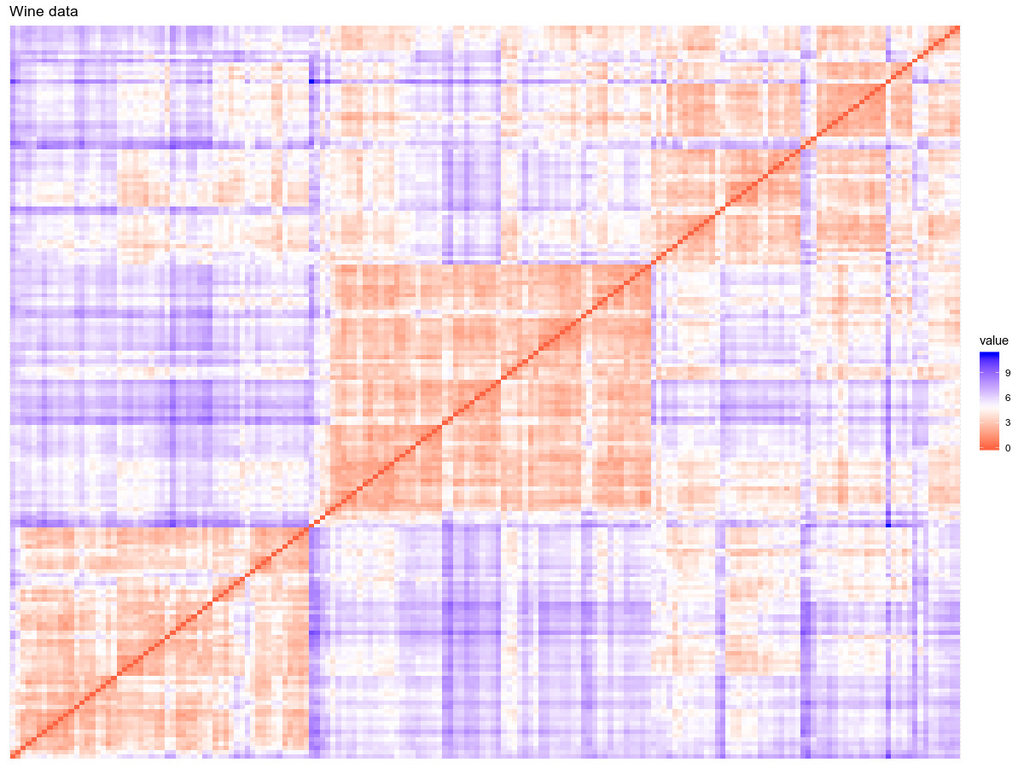

## Que perguntas a clusterização pode responder?

A clusterização é uma técnica de aprendizado não supervisionado cujo objetivo é identificar grupos de observações semelhantes, sem rótulos prévios. Ela é usada tanto como **objetivo final** quanto como **ferramenta de apoio à decisão**.

- **Como agrupo os clientes que compram no site?**  
  A clusterização permite identificar perfis de clientes com comportamentos de compra semelhantes, apoiando estratégias de segmentação e marketing.
- **Onde coloco uma antena de operadora de celular?**  
  A partir da clusterização espacial de usuários ou regiões, é possível identificar áreas de alta concentração de demanda, sugerindo locais estratégicos para instalação.

## Que perguntas a clusterização pode responder?

- **Onde deixo uma ambulância estacionada para atender uma emergência?**  
  A clusterização de ocorrências passadas ajuda a identificar zonas críticas, auxiliando na alocação eficiente de recursos de emergência.
- **Como classifico cervejas em categorias distintas?**  
  A clusterização explora similaridades entre produtos e pode revelar categorias naturais ou estilos semelhantes, apoiando a construção de classificações.

## Algumas questões…

🤔 Como medir a homogeneidade entre indivíduos?

🤔 E entre grupos de indivíduos?

🤔 Dado um conjunto de indivíduos, quantos grupos posso formar?

## Algumas questões…

Imagine que você tenha 16 cartas figuradas ($A,K,Q,J$) e que queira formar grupos de cartas semelhantes…

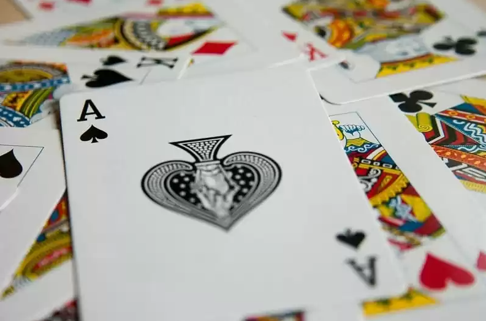

**Como você formaria esses grupos?**

## Algumas questões…

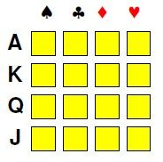

Cartas individuais?

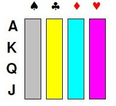

Agrupar por naipes?

## Algumas questões…

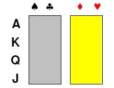

Agrupar por cor do naipe?

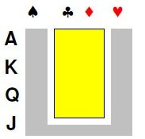

Agrupar por naipes maiores e menores?

## Algumas questões…

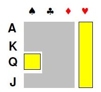

Copas mais a Rainha de espadas e outros naipes?

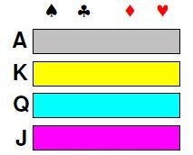

Agrupar por face da carta?

## Algumas questões…

### Resumindo…

**Necessidade** da definição de medidas de **similaridade** (ou dissimilaridade)

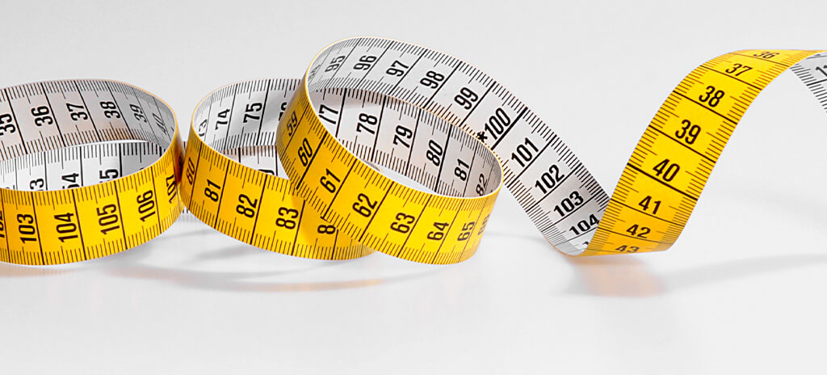

## Similaridade e dissimilaridade

**Medidas de Similaridade:** quanto **maior** o valor, **maior a semelhança** entre os objetos

**Medidas de Dissimilaridade (Distância):** quanto **maior** o valor, **mais diferentes** são os objetos

## Similaridade e dissimilaridade (exemplo)

**Pesquisa com clientes de uma loja de equipamentos automotivos**

**Variáveis mensuradas**

- **Idade** (em anos completos) - Variável quantitativa discreta
- **Número de carros** - Variável quantitativa discreta
- **Classe social**: A, B, C ou D - Variável qualitativa ordinal
- **Potência do motor**: Baixa, Média ou Alta - Variável qualitativa ordinal
- **Combustível**: Gasolina ou Álcool - Variável qualitativa nominal
- **Modelo**: Esporte, Luxo ou Standard - Variável qualitativa nominal

## Base de dados (exemplo)

| Cliente | **Idade** | **N.º de carros** | **Classe social** | **Potência do motor** | **Combustível** | **Modelo** |
| --- | --- | --- | --- | --- | --- | --- |
| 1 | 20 | 1 | A | Baixa | Gasolina | Esporte |
| 2 | 37 | 2 | A | Alta | Gasolina | Luxo |
| 3 | 51 | 1 | C | Média | Gasolina | Esporte |
| 4 | 32 | 1 | D | Alta | Álcool | Standard |
| 5 | 30 | 2 | B | Média | Álcool | Standard |
| 6 | 55 | 3 | A | Alta | Gasolina | Luxo |

**Como medir a similaridade ou dissimilaridade entre os indivíduos?**

# Variáveis quantitativas

## Dissimilaridade

As **distâncias** são as medidas de **dissimilaridade** mais utilizadas no estudo de bancos de dados com variáveis numéricas

- Uma medida $d_{ij}$ representa uma **medida de distância** entre os indivíduos $i$ e $j$ se, e somente se,
  1. $d_{ij} \geqslant 0$ para todo $i$ e $j$;
  2. $d_{ij} = 0$ se, e somente se, $i = j$;
  3. $d_{ij} = d_{ji}$
  4. $d_{ij} \leqslant d_{ik} + d_{kj}$ para qualquer indivíduo $k$.

## Dissimilaridade

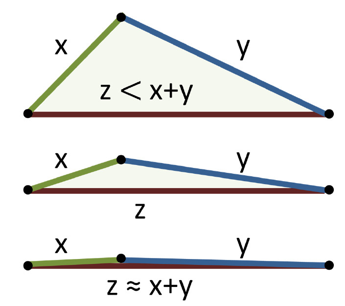

Desigualdade triangular

## Dissimilaridade

### Principais medidas de distância

**Distância Euclidiana**

$$d_{ij} = \displaystyle{\sqrt{(\mathbf{x}_i - \mathbf{x}_j)^t(\mathbf{x}_i - \mathbf{x}_j)}} = \sqrt{\displaystyle{\sum_{k=1}^p(x_{ik} - x_{jk})^2}}$$

Distância geométrica entre dois pontos

## Dissimilaridade

### Principais medidas de distância

**Distância Euclidiana Generalizada**

$$d_{ij} = \displaystyle{\sqrt{(\mathbf{x}_i - \mathbf{x}_j)^t\boldsymbol{W}(\mathbf{x}_i - \mathbf{x}_j)}}$$

- Se $\boldsymbol{W} = \textrm{diag}\left(\dfrac{1}{p}\right)$: **distância euclidiana média**
- Se $\boldsymbol{W} = \boldsymbol{\Sigma}^{-1}$: **distância de Mahalanobis**

## Dissimilaridade

### Principais medidas de distância

**Distância de Minkowski**

$$d_{ij} = \left( \displaystyle{\sum_{k=1}^P} |X_{ik} - X_{jk}|^{\lambda}\right)^{\frac{1}{\lambda}}$$

- Se $\lambda = 1$, temos a chamada **métrica de Manhattan**. É também conhecida como *city block*.
- Se $\lambda = 2$, temos a distância euclidiana.
- A métrica de Minkowski é menos afetada pela presença de valores discrepantes na amostra do que a distância Euclidiana.

## Dissimilaridade

### Principais medidas de distância

**Distância de Manhattan (city block)**

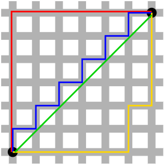

## Dissimilaridade

### Dissimilaridade $\Longrightarrow$ Similaridade

$$s_{ij} = 1 - d_{ij}^0$$

em que

$$d_{ij}^0 = \displaystyle{\frac{d_{ij} - \min(\boldsymbol{D})}{\max(\boldsymbol{D}) - \min(\boldsymbol{D})}}$$

Sendo $\min(\boldsymbol{D})$ e $\max(\boldsymbol{D})$ o menor e o maior valor de distância observados na matriz de distâncias $\boldsymbol{D}_{n \times n}$, sem levar em consideração os elementos da diagonal principal dessa matriz.

# Variáveis qualitativas

## Similaridade

### Variáveis qualitativas nominais

Neste caso, utilizamos variáveis fictícias (variáveis *dummy*) para **codificar** as variáveis:

| Combustível | $N_1$ |
| --- | --- |
| Gasolina | 1 |
| Álcool | 0 |

| Modelo | $N_2$ | $N_3$ |
| --- | --- | --- |
| Esporte | 1 | 0 |
| Luxo | 0 | 1 |
| Standard | 0 | 0 |

## Similaridade

### Variáveis qualitativas nominais

**No exemplo:**

| Cliente | Combustível | $N_1$ |
| --- | --- | --- |
| 1 | Gasolina | 1 |
| 2 | Gasolina | 1 |
| 3 | Gasolina | 1 |
| 4 | Álcool | 0 |
| 5 | Álcool | 0 |
| 6 | Gasolina | 1 |

| Cliente | Modelo | $N_2$ | $N_3$ |
| --- | --- | --- | --- |
| 1 | Esporte | 1 | 0 |
| 2 | Luxo | 0 | 1 |
| 3 | Esporte | 1 | 0 |
| 4 | Standard | 0 | 0 |
| 5 | Standard | 0 | 0 |
| 6 | Luxo | 0 | 1 |

## Similaridade

### Variáveis qualitativas nominais

De forma que,

| Cliente | $N_1$ | $N_2$ | $N_3$ |
| --- | --- | --- | --- |
| 1 | 1 | 1 | 0 |
| 2 | 1 | 0 | 1 |
| 3 | 1 | 1 | 0 |
| 4 | 0 | 0 | 0 |
| 5 | 0 | 0 | 0 |
| 6 | 1 | 0 | 1 |

## Similaridade

### Variáveis qualitativas ordinais

Utilizamos variáveis fictícias (variáveis *dummy*) para **codificar** as variáveis, levando em consideração a ordinalidade das variáveis:

| Classe social | $O_1$ | $O_2$ | $O_3$ |
| --- | --- | --- | --- |
| A | 1 | 1 | 1 |
| B | 0 | 1 | 1 |
| C | 0 | 0 | 1 |
| D | 0 | 0 | 0 |

| Potência | $O_4$ | $O_5$ |
| --- | --- | --- |
| Alta | 1 | 1 |
| Média | 0 | 1 |
| Baixa | 0 | 0 |

## Similaridade

### Observação

As variáveis **Classe social** e **Potência do motor** possuem **ordem natural**. Por isso, foram codificadas por meio de **variáveis ordinais cumulativas**:

- valores mais altos acumulam mais indicadores iguais a 1;
- valores mais baixos recebem apenas zeros.

Essa codificação preserva a informação de ordem, mas impõe uma estrutura geométrica específica ao espaço dos dados.

## Similaridade

### Variáveis qualitativas ordinais

**No exemplo:**

| Cliente | Classe social | $O_1$ | $O_2$ | $O_3$ |
| --- | --- | --- | --- | --- |
| 1 | A | 1 | 1 | 1 |
| 2 | A | 1 | 1 | 1 |
| 3 | C | 0 | 0 | 1 |
| 4 | D | 0 | 0 | 0 |
| 5 | B | 0 | 1 | 1 |
| 6 | A | 1 | 1 | 1 |

| Cliente | Potência | $O_4$ | $O_5$ |
| --- | --- | --- | --- |
| 1 | Baixa | 0 | 0 |
| 2 | Alta | 1 | 1 |
| 3 | Média | 0 | 1 |
| 4 | Alta | 1 | 1 |
| 5 | Média | 0 | 1 |
| 6 | Alta | 1 | 1 |

## Similaridade

### Variáveis qualitativas ordinais

De forma que,

| Cliente | $O_1$ | $O_2$ | $O_3$ | $O_4$ | $O_5$ |
| --- | --- | --- | --- | --- | --- |
| 1 | 1 | 1 | 1 | 0 | 0 |
| 2 | 1 | 1 | 1 | 1 | 1 |
| 3 | 0 | 0 | 1 | 0 | 1 |
| 4 | 0 | 0 | 0 | 1 | 1 |
| 5 | 0 | 1 | 1 | 0 | 1 |
| 6 | 1 | 1 | 1 | 1 | 1 |

## Similaridade

### Variáveis qualitativas nominais e ordinais

Juntando tudo…

| Cliente | $O_1$ | $O_2$ | $O_3$ | $O_4$ | $O_5$ | $N_1$ | $N_2$ | $N_3$ |
| --- | --- | --- | --- | --- | --- | --- | --- | --- |
| 1 | 1 | 1 | 1 | 0 | 0 | 1 | 1 | 0 |
| 2 | 1 | 1 | 1 | 1 | 1 | 1 | 0 | 1 |
| 3 | 0 | 0 | 1 | 0 | 1 | 1 | 1 | 0 |
| 4 | 0 | 0 | 0 | 1 | 1 | 0 | 0 | 0 |
| 5 | 0 | 1 | 1 | 0 | 1 | 0 | 0 | 0 |
| 6 | 1 | 1 | 1 | 1 | 1 | 1 | 0 | 1 |

## Similaridade

### Variáveis qualitativas nominais e ordinais

Considere os clientes 1 e 3. Vamos calcular a medida de similaridade entre eles:

| Cliente | $O_1$ | $O_2$ | $O_3$ | $O_4$ | $O_5$ | $N_1$ | $N_2$ | $N_3$ |
| --- | --- | --- | --- | --- | --- | --- | --- | --- |
| 1 | 1 | 1 | 1 | 0 | 0 | 1 | 1 | 0 |
| 3 | 0 | 0 | 1 | 0 | 1 | 1 | 1 | 0 |

## Similaridade

### Tabela de concordância entre dois indivíduos

| Indivíduo $i$ \ Indivíduo $j$ | 1 | 0 | Total |
| --- | --- | --- | --- |
| 1 | $a$ | $b$ | $a + b$ |
| 0 | $c$ | $d$ | $c + d$ |
| **Total** | $a + c$ | $b + d$ | $p$ |

- $a$: número de variáveis em que ambos têm valor 1
- $b$: número de variáveis em que $i=1$ e $j=0$
- $c$: número de variáveis em que $i=0$ e $j=1$
- $d$: número de variáveis em que ambos têm valor 0

$$p = a + b + c + d$$

## Similaridade

### Tabela de concordância entre dois indivíduos

**No exemplo:**

| Indivíduo 1 \ Indivíduo 3 | 1 | 0 | Total |
| --- | --- | --- | --- |
| 1 | 3 | 2 | 5 |
| 0 | 1 | 2 | 3 |
| **Total** | 4 | 4 | 8 |

# Como extrair as **medidas de similaridade** baseadas na **tabela de concordância** dos elementos?

## Critérios de similaridade

### Coeficiente de Concordância Simples

$$\Large s_{ij} = \displaystyle{\frac{a + d}{p}}$$

| Indivíduo 1 \ Indivíduo 3 | 1 | 0 | Total |
| --- | --- | --- | --- |
| 1 | 3 | 2 | 5 |
| 0 | 1 | 2 | 3 |
| **Total** | 4 | 4 | 8 |

$$s_{13} = \dfrac{a + d}{p}
= \dfrac{3 + 2}{8}
= \dfrac{5}{8}
= 0,625$$

## Critérios de similaridade

### Coeficiente de Concordância Simples

**Interpretação:**

- O valor 0,625 indica que os indivíduos 1 e 3 concordam em 62,5% das variáveis binárias.
- Tanto concordâncias em 1 quanto em 0 contribuem igualmente para a similaridade.

## Critérios de similaridade

### Coeficiente de Concordância Positiva

$$\Large s_{ij} = \displaystyle{\frac{a}{p}}$$

| Indivíduo 1 \ Indivíduo 3 | 1 | 0 | Total |
| --- | --- | --- | --- |
| 1 | 3 | 2 | 5 |
| 0 | 1 | 2 | 3 |
| **Total** | 4 | 4 | 8 |

$$s_{13} = \dfrac{a}{p}=
\dfrac{3}{8} = 0,375$$

## Critérios de similaridade

### Coeficiente de Concordância Positiva

**Interpretação:**

- Os indivíduos 1 e 3 compartilham simultaneamente o valor 1 em **37,5%** das variáveis.
- Ausências simultâneas (valor 0) **não contribuem** para a similaridade.
- O critério enfatiza **presença conjunta**, não coincidência geral.

## Critérios de similaridade

### Coeficiente de Concordância de Jaccard

$$\Large s_{ij} = \displaystyle{\frac{a}{a + b + c}}$$

| Indivíduo 1 \ Indivíduo 3 | 1 | 0 | Total |
| --- | --- | --- | --- |
| 1 | 3 | 2 | 5 |
| 0 | 1 | 2 | 3 |
| **Total** | 4 | 4 | 8 |

$$s_{13} = \dfrac{3}{3 + 2 + 1}
= \dfrac{3}{6}
= 0,5$$

## Critérios de similaridade

### Coeficiente de Concordância de Jaccard

**Interpretação:**

- Os indivíduos 1 e 3 compartilham **50% das presenças observadas**.
- Ausências simultâneas (valor 0) **não contribuem** para a similaridade.
- O coeficiente foca exclusivamente na **interseção de atributos presentes**.

## Critérios de similaridade

### Coeficiente de Concordância de Gower e Legendre

O **Coeficiente de Concordância de Gower–Legendre** é uma medida de similaridade projetada para **dados mistos**, isto é, conjuntos de dados que contêm, ao mesmo tempo:

- variáveis quantitativas,
- variáveis qualitativas nominais,
- variáveis qualitativas ordinais.

Ele permite combinar diferentes tipos de variáveis em **uma única medida de similaridade**, respeitando a natureza de cada uma.

## Critérios de similaridade

### Coeficiente de Concordância de Gower e Legendre

Considere dois indivíduos $i$ e $j$ descritos por $p$ variáveis. A similaridade de Gower–Legendre é definida como:

$$S_{ij}
=
\dfrac{\sum_{k=1}^{p} w_{ijk}\, s_{ijk}}
{\sum_{k=1}^{p} w_{ijk}},$$
onde:

- $s_{ijk}$ é a similaridade parcial da variável $k$ entre os indivíduos $i$ e $j$;
- $w_{ijk}$ é um peso (geralmente $0$ ou $1$), usado para tratar dados ausentes.

## Critérios de similaridade

### Coeficiente de Concordância de Gower e Legendre

O coeficiente assume valores em $[0,1]$:

- $S_{ij} = 1$ indica indivíduos idênticos;
- $S_{ij} = 0$ indica máxima dissimilaridade.

## Critérios de similaridade

### Coeficiente de Concordância de Gower e Legendre

#### Similaridade parcial por tipo de variável

**Variáveis quantitativas**

- Para uma variável quantitativa $k$:

$$s_{ijk}
=
1 - \dfrac{|x_{ik} - x_{jk}|}{R_k},$$

onde $R_k$ é o intervalo da variável $k$ (máximo − mínimo).

## Critérios de similaridade

### Coeficiente de Concordância de Gower e Legendre

#### Similaridade parcial por tipo de variável

**Variáveis qualitativas nominais**

- Para uma variável nominal:

$$s_{ijk}
=
\begin{cases}
1, & \text{se } x_{ik} = x_{jk}, \\
0, & \text{caso contrário}.
\end{cases}$$

## Critérios de similaridade

### Coeficiente de Concordância de Gower e Legendre

#### Similaridade parcial por tipo de variável

**Variáveis qualitativas ordinais**

Para variáveis ordinais, os níveis são primeiro convertidos em **postos normalizados** no intervalo $[0,1]$. Em seguida, aplica-se a mesma fórmula das variáveis quantitativas:

$$s_{ijk}
=
1 - |r_{ik} - r_{jk}|,$$

onde $r_{ik}$ e $r_{jk}$ são os postos normalizados.

## Critérios de similaridade

### Coeficiente de Concordância de Gower e Legendre

**Interpretação:**

- Cada variável contribui **de forma controlada** para a similaridade total.
- Variáveis com escalas diferentes **não dominam** o cálculo.
- A ordem das categorias é respeitada para variáveis ordinais, **sem impor distâncias artificiais**.

## Critérios de similaridade

### Similaridade $\Longrightarrow$ Dissimilaridade

$$\Large d_{ij}^* = 1 - s_{ij}$$

## Critérios de similaridade

### Coeficiente de Concordância de Gower e Legendre

**No exemplo:**

| Cliente | **Idade** | **N.º de carros** | **Classe social** | **Potência do motor** | **Combustível** | **Modelo** |
| --- | --- | --- | --- | --- | --- | --- |
| 1 | 20 | 1 | A | Baixa | Gasolina | Esporte |
| 2 | 37 | 2 | A | Alta | Gasolina | Luxo |
| 3 | 51 | 1 | C | Média | Gasolina | Esporte |
| 4 | 32 | 1 | D | Alta | Álcool | Standard |
| 5 | 30 | 2 | B | Média | Álcool | Standard |
| 6 | 55 | 3 | A | Alta | Gasolina | Luxo |

## Critérios de similaridade

### Coeficiente de Concordância de Gower e Legendre

Temos que:

- **Cliente 1:** Idade = 20, Carros = 1, Classe = A, Potência = Baixa, Combustível = Gasolina, Modelo = Esporte
- **Cliente 3:** Idade = 51, Carros = 1, Classe = C, Potência = Média, Combustível = Gasolina, Modelo = Esporte

## Critérios de similaridade

### Coeficiente de Concordância de Gower e Legendre

#### Similaridades parciais

- **Idade**

$$s=\;1-\dfrac{|20-51|}{35}=1-\dfrac{31}{35}=\dfrac{4}{35}\approx 0,1143$$

- **Nº de carros**

$$s=\;1-\dfrac{|1-1|}{2}=1$$

## Critérios de similaridade

### Coeficiente de Concordância de Gower e Legendre

#### Similaridades parciais

- **Classe social (ordinal)**

$r(A)=1$ e $r(C)=\tfrac{1}{3}$:
$$s=\;1-\left|1-\tfrac{1}{3}\right|=1-\tfrac{2}{3}=\tfrac{1}{3}\approx 0,3333$$

- **Potência (ordinal)**

$r(\text{Baixa})=0$ e $r(\text{Média})=\tfrac{1}{2}$:
$$s=\;1-\left|0-\tfrac{1}{2}\right|=\tfrac{1}{2}=0,5$$

## Critérios de similaridade

### Coeficiente de Concordância de Gower e Legendre

#### Similaridades parciais

- **Combustível (nominal)**

Gasolina = Gasolina $\Rightarrow s=1$

- **Modelo (nominal)**

Esporte = Esporte $\Rightarrow s=1$

## Critérios de similaridade

### Coeficiente de Concordância de Gower e Legendre

#### Similaridade total

São $p=6$ variáveis:
$$S_{1,3}
=\dfrac{0,1143+1+0,3333+0,5+1+1}{6}
\approx 0,6579$$

# Métodos de Agrupamento

## Métodos hierárquicos

- **Aglomerativos:** Os agrupamentos são formados a partir de uma matriz de parecença, que é atualizada a cada união de um par de objetos. Neste procedimento, cada indivíduo, originalmente, é um cluster, configurando $n$ clusters. Indivíduos similares são sucessivamente agrupados, até a formação de um único grupo, contendo toda a amostra.

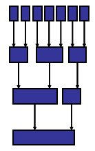

## Métodos hierárquicos

- **Divisivos (ou de Partição):** Fazem o caminho oposto aos métodos hierárquicos aglomerativos. Neste método, um único grupo de objetos é subdividido em dois com a maior distância. Estes subgrupos são então particionados sucessivamente até se obter os objetos individuais.

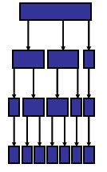

## Métodos de Agrupamento Hierárquicos

### Agrupamentos hierárquicos aglomerativos

1. Considerar inicialmente $n$ grupos, sendo $n$ o número de indivíduos. A matriz de distâncias $\boldsymbol{D}_{n \times n}$ é a matriz de distâncias entre os elementos originais;
2. Selecionar os dois indivíduos mais próximos na matriz $\boldsymbol{D}_{n \times n}$ e formar com eles um grupo;
3. Substituir os indivíduos utilizados no passo b) para definir o grupo por um novo elemento que represente o grupo construído. A distância entre esse novo elemento e os indivíduos restantes são calculadas utilizando um dos critérios que serão definidos a seguir;
4. Voltar ao passo b) e repetir os passos b) e c) até que tenhamos todos os elementos agrupados em um único grupo.

## Métodos de Agrupamento Hierárquicos

### Resultado da aplicação do método

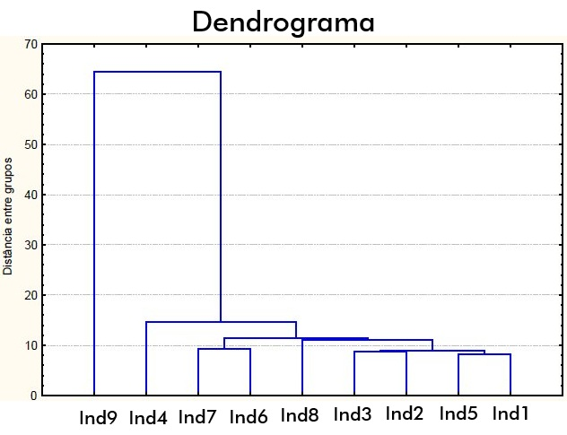

- Representa uma síntese gráfica do método de agrupamento
- Esse gráfico é de grande utilidade para a classificação, comparação e discussão de agrupamentos.

## Métodos de Agrupamento Hierárquicos

### Como definir distância entre grupos?

- Suponha que temos um grupo $K$ com $n_k$ indivíduos e um grupo $L$ com $n_l$ indivíduos.
- A distância entre os grupos $K$ e $L$ pode ser calculada com base em um dos cinco métodos seguintes:
  - Método do vizinho mais próximo (*single linkage*)
  - Método do vizinho mais distante (*complete linkage*)
  - Método da distância média (*average linkage*)
  - Método do centroide (*Centroid*)
  - Método de Ward

## Métodos de Agrupamento Hierárquicos

### Método do vizinho mais próximo

Consiste em considerar que a distância entre os dois grupos é a **menor distância entre as possíveis combinações de indivíduos** tomados dos dois grupos considerados, isto é,

$$\Large d_{(K,L)} = \underbrace{\min(d_{ij})}_{i \in K, j \in L}$$

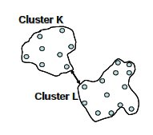

## Métodos de Agrupamento Hierárquicos

### Método do vizinho mais próximo

**Esquematicamente:**

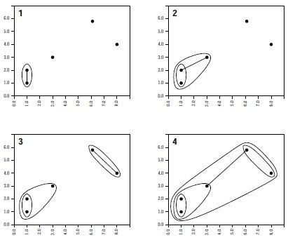

## Métodos de Agrupamento Hierárquicos

### Método do vizinho mais próximo

**Esquematicamente:**

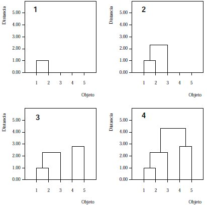

## Métodos de Agrupamento Hierárquicos

### Método do vizinho mais distante

Consiste em considerar que a distância entre os dois grupos é a **maior distância entre as possíveis combinações de indivíduos** tomados dos dois grupos considerados, isto é,

$$\Large d_{(K,L)} = \underbrace{\max(d_{ij})}_{i \in K, j \in L}$$

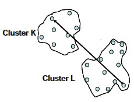

## Métodos de Agrupamento Hierárquicos

### Método da distância média

Consiste em considerar que a distância entre os dois grupos é a **média aritmética das distâncias entre as possíveis combinações de indivíduos** tomados dos dois grupos considerados, isto é,

$$\Large d_{(K,L)} = \displaystyle{\sum_{i \in K} \sum_{j \in L}} \displaystyle{\frac{d_{ij}}{n_kn_l}}$$

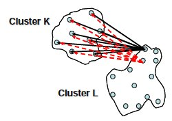

## Métodos de Agrupamento Hierárquicos

### Método do centroide

Consiste em considerar que a distância entre os dois grupos é a **distância euclidiana ao quadrado entre os centroides** dos dois grupos. O centroide de um grupo é o ponto médio dos objetos contidos no grupo, isto é,

$$\Large d_{(K,L)} = (\bar{K} - \bar{L})^t(\bar{K} - \bar{L})$$

$$\bar{K} = \displaystyle{\frac{\displaystyle{\sum_{i \in K} i}}{n_k}} \hspace{0.2cm} {\rm e} \hspace{0.2cm}
\bar{L} = \displaystyle{\frac{\displaystyle{\sum_{j \in L} j}}{n_l}}$$

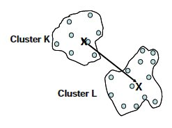

## Métodos de Agrupamento Hierárquicos

### Método de Ward

- Considere a soma de quadrados intra-cluster de um cluster $A$:

$$SQE_A = \displaystyle{\sum_{i = 1}^{n_A}}(x_{i} - \bar{\bf x}_A)^t(x_{i} - \bar{\bf x}_A)$$

- Definimos o acréscimo na soma de quadrados resultante da junção de dois clusters $A$ e $B$ em um cluster $AB$ por:

$$I_{AB} = SQE_{AB} - (SQE_A + SQE_B)$$

## Métodos de Agrupamento Hierárquicos

### Método de Ward

- A união entre clusters $A$ e $B$ que proporcionarem menor acréscimo na $SQE$ é executada.
- Para usar o método de Ward, as variáveis devem ser **quantitativas**.

## Métodos de Agrupamento Hierárquicos

### Exemplo

A fim de exemplificar a aplicação dos métodos de agrupamento, considere os dados da Tabela ao lado. Os sete casos são considerados as observações de cada indivíduo para as variáveis $X_1$ e $X_2$.

| Caso | $X_1$ | $X_2$ |
| --- | --- | --- |
| 1 | 1 | 1 |
| 2 | 2 | 1 |
| 3 | 3 | 2 |
| 4 | 2 | 4,5 |
| 5 | 1 | 5 |
| 6 | 3 | 7 |
| 7 | 6 | 5 |

## Métodos de Agrupamento Hierárquicos

### Exemplo

**Representação dos casos no plano**

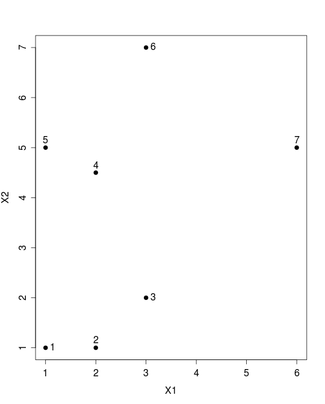

## Métodos de Agrupamento Hierárquicos

### Exemplo

**Matriz de distâncias**

$$D_0 = \left[ \begin{matrix}
&1 & 2&3&4&5&6&7\\
1& 0,000 & 1,000 & 2,236 & 3,640 & 4,000 & 6,325 & 6,403 \\
2& & 0,000 & 1,414 & 3,500 & 4,123 & 6,083 & 5,657 \\
3& & & 0,000 & 2,693 & 3,606 & 5,000 & 4,243 \\
4& & & & 0,000 & 1,118 & 2,693 & 4,031 \\
5& & & & & 0,000 & 2,828 & 5,000 \\
6& & & & & & 0,000 & 3,606 \\
7& & & & & & & 0,000
\end{matrix} \right]$$

## Métodos de Agrupamento Hierárquicos

### Exemplo

**Matriz de distâncias**

$$D_0 = \left[ \begin{matrix}
&1 & 2&3&4&5&6&7\\
1& 0,000 & \textbf{1,000} & 2,236 & 3,640 & 4,000 & 6,325 & 6,403 \\
2& & 0,000 & 1,414 & 3,500 & 4,123 & 6,083 & 5,657 \\
3& & & 0,000 & 2,693 & 3,606 & 5,000 & 4,243 \\
4& & & & 0,000 & 1,118 & 2,693 & 4,031 \\
5& & & & & 0,000 & 2,828 & 5,000 \\
6& & & & & & 0,000 & 3,606 \\
7& & & & & & & 0,000
\end{matrix} \right]$$

$$\scriptsize d_{12} = \sqrt{\displaystyle{(X_{11} - X_{21})^2 + (X_{12} - X_{22})^2}} =
\sqrt{\displaystyle{(1 - 1)^2 + (2 - 1)^2}} = \sqrt{1} = 1$$

## Métodos de Agrupamento Hierárquicos

### Exemplo

**Passo 1: juntar os casos 1 e 2**

- Redefinir a matriz de distâncias considerando os casos mais parecidos como se fossem um único grupo.
- **Aqui os métodos se diferenciam!**
- **Método do vizinho mais próximo**

## Métodos de Agrupamento Hierárquicos

### Exemplo

**Construção da nova matriz de distâncias**

$$\begin{aligned}
d_{((1,2)3)} &= \min(d_{13};d_{23}) = \min(2,236; 1,414) = 1,414 \\[6pt]
d_{((1,2)4)} &= \min(d_{14};d_{24}) = \min(3,640; 3,500) = 3,500 \\[6pt]
d_{((1,2)5)} &= \min(d_{15};d_{25}) = \min(4,000; 4,123) = 4,000 \\[6pt]
d_{((1,2)6)} &= \min(d_{16};d_{26}) = \min(6,325; 6,083) = 6,083 \\[6pt]
d_{((1,2)7)} &= \min(d_{17};d_{27}) = \min(6,403; 5,657) = 5,657
\end{aligned}$$

## Métodos de Agrupamento Hierárquicos

### Exemplo

**Matriz de distâncias**

$$D_1 = \left[ \begin{matrix}
&(1,2)&3&4&5&6&7\\
(1,2)& 0,000 & 1,414 & 3,500 & 4,000 & 6,083 & 5,657 \\
3 & & 0,000 & 2,693 & 3,606 & 5,000 & 4,243 \\
4 & & & 0,000 & 1,118 & 2,693 & 4,031 \\
5 & & & & 0,000 & 2,828 & 5,000 \\
6 & & & & & 0,000 & 3,606 \\
7 & & & & & & 0,000
\end{matrix} \right]$$

## Métodos de Agrupamento Hierárquicos

### Exemplo

**Matriz de distâncias**

$$D_1 = \left[ \begin{matrix}
&(1,2)&3&4&5&6&7\\
(1,2)& 0,000 & 1,414 & 3,500 & 4,000 & 6,083 & 5,657 \\
3 & & 0,000 & 2,693 & 3,606 & 5,000 & 4,243 \\
4 & & & 0,000 & \textbf{1,118} & 2,693 & 4,031 \\
5 & & & & 0,000 & 2,828 & 5,000 \\
6 & & & & & 0,000 & 3,606 \\
7 & & & & & & 0,000
\end{matrix} \right]$$

## Métodos de Agrupamento Hierárquicos

### Exemplo

**Passo 2: juntar os casos 4 e 5**

**Redefinir a matriz de distâncias considerando os casos mais parecidos como se fossem um único grupo.**

$$\begin{aligned}
d_{((4,5)(1,2))} &= \min(d_{14};d_{24};d_{15};d_{25}) = \min(3,640; 3,500; 4,000; 4,123) = 3,500 \\ &=
\min(d_{(1,2)4};d_{(1,2)5}) = \min(3,500;4,000) \\
d_{((4,5)3)} &= \min(d_{34};d_{35}) = \min(2,693; 3,606) = 2,693 \\
d_{((4,5)6)} &= \min(d_{46};d_{56}) = \min(2,693; 2,828) = 2,693 \\
d_{((4,5)7)} &= \min(d_{47};d_{57}) = \min(4,031; 5,000) = 4,031
\end{aligned}$$

## Métodos de Agrupamento Hierárquicos

### Exemplo

**Matriz de distâncias**

$$D_2 = \left[ \begin{matrix}
&(1,2)&3&(4,5)&6&7\\
(1,2)& 0,000 & 1,414 & 3,500 & 6,083 & 5,657 \\
3 & & 0,000 & 2,693 & 5,000 & 4,243 \\
(4,5) & & & 0,000 & 2,693 & 4,031 \\
6 & & & & 0,000 & 3,606 \\
7 & & & & & 0,000
\end{matrix} \right]$$

## Métodos de Agrupamento Hierárquicos

### Exemplo

**Matriz de distâncias**

$$D_2 = \left[ \begin{matrix}
&(1,2)&3&(4,5)&6&7\\
(1,2)& 0,000 & \textbf{1,414} & 3,500 & 6,083 & 5,657 \\
3 & & 0,000 & 2,693 & 5,000 & 4,243 \\
(4,5) & & & 0,000 & 2,693 & 4,031 \\
6 & & & & 0,000 & 3,606 \\
7 & & & & & 0,000
\end{matrix} \right]$$

## Métodos de Agrupamento Hierárquicos

### Exemplo

**Passo 3: juntar o grupo $(1,2)$ como caso 3**

**Redefinir a matriz de distâncias considerando os casos mais parecidos como se fossem um único grupo.**

$$\small
\begin{aligned}
d_{(((1,2,3)(4,5))} &= \min(d_{14};d_{24};d_{34};d_{15};d_{25};d_{35}) \\ &= \min(3,640; 3,500; 2,693; 4,000; 4,123; 3,606) = 2,693 \\ &=
\min(d_{(1,2)(4,5)};d_{(4,5)3}) = \min(3,500;2,693) \\
d_{((1,2,3)6)} &= \min(d_{16};d_{26};d_{36}) = \min(6,325; 6,083; 5,000) = 5,000 \\ &= \min(d_{((1,2)6)};d_{36}) = \min(6,083;5,000) \\
d_{((1,2,3)7)} &= \min(d_{17};d_{27};d_{37}) = \min(6,403; 5,657; 4,243) = 4,243 \\ &= \min(d_{((1,2)7)};d_{37}) = \min(5,657;4,243) \\
\end{aligned}$$

## Métodos de Agrupamento Hierárquicos

### Exemplo

**Matriz de distâncias**

$$D_3 = \left[ \begin{matrix}
&(1,2,3) &(4,5)&6&7\\
(1,2,3)& 0,000 & 2,693 & 5,000 & 4,243 \\
(4,5) & & 0,000 & 2,693 & 4,031 \\
6 & & & 0,000 & 3,606 \\
7 & & & & 0,000
\end{matrix} \right]$$

## Métodos de Agrupamento Hierárquicos

### Exemplo

**Matriz de distâncias**

$$D_3 = \left[ \begin{matrix}
&(1,2,3) &(4,5)&6&7\\
(1,2,3)& 0,000 & \textbf{2,693} & 5,000 & 4,243 \\
(4,5) & & 0,000 & \textbf{2,693} & 4,031 \\
6 & & & 0,000 & 3,606 \\
7 & & & & 0,000
\end{matrix} \right]$$

## Métodos de Agrupamento Hierárquicos

### Exemplo

**Passo 4: juntar o grupo $(4,5)$ como caso 6**

**Redefinir a matriz de distâncias considerando os casos mais parecidos como se fossem um único grupo.**

$$\small
\begin{aligned}
d_{(((4,5,6)(1,2,3))} &= \min(d_{14};d_{24};d_{34};d_{15};d_{25};d_{35};d_{16};d_{26};d_{36}) \\
&= \min(3,640; 3,500; 2,693; 4,000; 4,123; 3,606; 6,325; 6,083; 5,000) = 2,693 \\ &=
\min(d_{(1,2,3)(4,5)};d_{(1,2,3)6}) = \min(2,693; 5,000) \\
d_{((4,5,6)7)} &= \min(d_{47};d_{57};d_{67}) = \min(4,031; 5,000; 3,606) = 3,606 \\ &= \min(d_{((4,5)7)};d_{67}) = \min(4,031;3,606) \\
\end{aligned}$$

## Métodos de Agrupamento Hierárquicos

### Exemplo

**Matriz de distâncias**

$$D_4 = \left[ \begin{matrix}
&(1,2,3) &(4,5,6) &7\\
(1,2,3)& 0,000 & 2,693 & 4,243 \\
(4,5,6) & & 0,000 & 3,606 \\
7 & & & 0,000
\end{matrix} \right]$$

## Métodos de Agrupamento Hierárquicos

### Exemplo

**Matriz de distâncias**

$$D_4 = \left[ \begin{matrix}
&(1,2,3) &(4,5,6) &7\\
(1,2,3)& 0,000 & \textbf{2,693} & 4,243 \\
(4,5,6) & & 0,000 & 3,606 \\
7 & & & 0,000
\end{matrix} \right]$$

## Métodos de Agrupamento Hierárquicos

### Exemplo

**Passo 5: juntar o grupo $(1,2,3)$ com o grupo $(4,5,6)$**

**Redefinir a matriz de distâncias considerando os casos mais parecidos como se fossem um único grupo.**

$$\begin{aligned}
d_{((1,2,3,4,5,6)7)} &= \min(d_{17};d_{27};d_{37};d_{47};d_{57};d_{67}) \\
&= \min(6,403; 5,657; 4,243; 4,031; 5,000; 3,606) = 3,606 \\ &=
\min(d_{(1,2,3)7};d_{(4,5,6)7}) = \min(4,243; 3,606) \\
\end{aligned}$$

## Métodos de Agrupamento Hierárquicos

### Exemplo

**Matriz de distâncias**

$$D_5 = \left[ \begin{matrix}
&(1,2,3,4,5,6) & 7\\
(1,2,3,4,5,6 )& 0,000 & 3,606 \\
7 & & 0,000
\end{matrix} \right]$$

## Métodos de Agrupamento Hierárquicos

### Exemplo

**Matriz de distâncias**

$$D_5 = \left[ \begin{matrix}
&(1,2,3,4,5,6) & 7\\
(1,2,3,4,5,6 )& 0,000 & \textbf{3,606} \\
7 & & 0,000
\end{matrix} \right]$$

## Métodos de Agrupamento Hierárquicos

### Exemplo

**Resumo do método de agrupamento**

| Passo | Nº de grupos | Grupos | Distância |
| --- | --- | --- | --- |
| 1 | 7 | 1, 2, 3, 4, 5, 6, 7 | 0,000 |
| 2 | 6 | (1,2), 3, 4, 5, 6, 7 | 1,000 |
| 3 | 5 | (1,2), 3, (4,5), 6, 7 | 1,118 |
| 4 | 4 | (1,2,3), (4,5), 6, 7 | 1,414 |
| 5 | 3 | (1,2,3), (4,5,6), 7 | 2,693 |
| 6 | 2 | (1,2,3,4,5,6), 7 | 2,693 |
| 7 | 1 | (1,2,3,4,5,6,7) | 3,606 |

## Métodos de Agrupamento Hierárquicos

### Exemplo

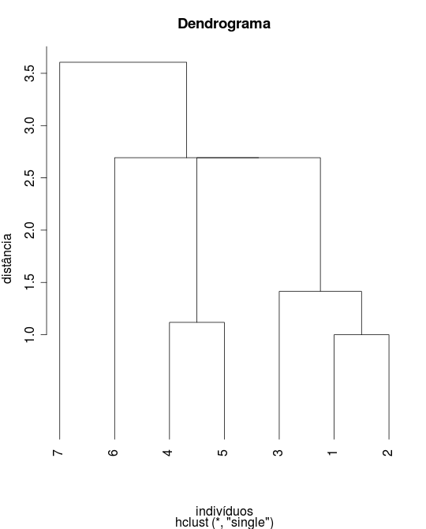

## Métodos de Agrupamento Hierárquicos

### Determinação do número de grupos

- O dendrograma permite ao pesquisador consultar a distância em que os clusters foram combinados para formar um novo cluster.
- Clusters que são semelhantes entre si são combinados a baixas distâncias, enquanto grupos que são mais dissimilares são combinados em altas distâncias.
- A diferença de distâncias define como os clusters próximos são um do outro.

## Métodos de Agrupamento Hierárquicos

### Determinação do número de grupos

- Uma partição dos dados em um número especificado de grupos pode ser obtida “cortando” o dendograma a uma distância apropriada.
- Se traçarmos uma linha horizontal no dendograma a uma determinada distância, então o número $k$ das linhas verticais cortadas por essa linha horizontal identificará uma solução $k$-cluster.
- A intersecção da linha horizontal e uma dessas linhas verticais representa um cluster, e os itens localizados no final de todos os ramos abaixo interseção constituem os membros do cluster.

## Métodos de Agrupamento Hierárquicos

### Determinação do número de grupos

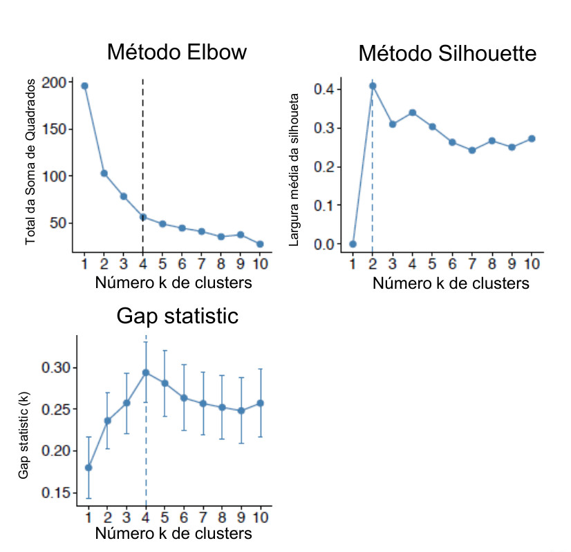

## Métodos hierárquicos: comentários finais

- Fontes de erros e de variação não são formalmente considerados nos procedimentos hierárquicos: Significa que esses métodos são sensíveis a outliers ou pontos de perturbação
- Deve-se sempre verificar a sensibilidade da configuração dos grupos: Os métodos não permitem a realocação de objetos que possam ter sido agrupados incorretamente nos estágios iniciais
- É recomendado tentar vários métodos de agrupamento e de atribuição de distâncias (similaridades)
- Empates na matriz de distâncias podem produzir múltiplas soluções ao problema de agrupamento hierárquico

## Métodos hierárquicos: comentários finais

- A maioria dos métodos produz clusters esféricos ou elípticos
- O método de **ligação simples** é um dos poucos métodos que pode delinear cluster não-elípticos
  - Tem a capacidade de gerar estruturas geométricas diferentes
  - Entretanto, ele é incapaz de perceber grupos pouco separados
- Os clusters formados pelo método de ligação simples não serão modificados por qualquer atribuição de distância (similaridade) que dá as mesmas ordenações relativas

## Métodos hierárquicos: comentários finais

- O método de **ligação completa** tende a produzir conglomerados de aproximadamente mesmo diâmetro
  - Tem a tendência de isolar os valores discrepantes nos estágios iniciais do agrupamento
- O método da **média das distâncias** tende a produzir conglomerados de aproximadamente mesma variância interna
  - Em geral, produz melhores partições que os métodos de ligação simples e completa

## Métodos hierárquicos: comentários finais

- Os métodos de ligação simples, completa e da média podem ser utilizados tanto para **variáveis quantitativas** quanto para **variáveis qualitativas**
- Os métodos do centróide e de Ward são apropriados apenas para **variáveis quantitativas**
- O **método de Ward** tende a produzir grupos com aproximadamente o mesmo número de elementos
- Espera-se sempre que haja uma certa consistência entre as soluções obtidas por métodos diferentes: pode não ocorrer a igualdade das soluções apresentadas pelos vários métodos

## Validação dos agrupamentos

- MANOVA
- Análise Discriminante
- Correlação Cofenética
- Gráfico da Silhueta

## Validação dos agrupamentos

### Correlação Cofenética

- Medida de validação usada nos métodos hierárquicos principalmente
- **Idéia:** realizar uma comparação das distâncias observadas e preditas (via a formação de agrupamentos) entre os objetos

## Validação dos agrupamentos

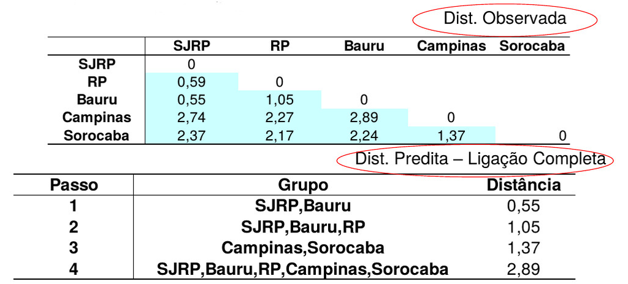

## Validação dos agrupamentos

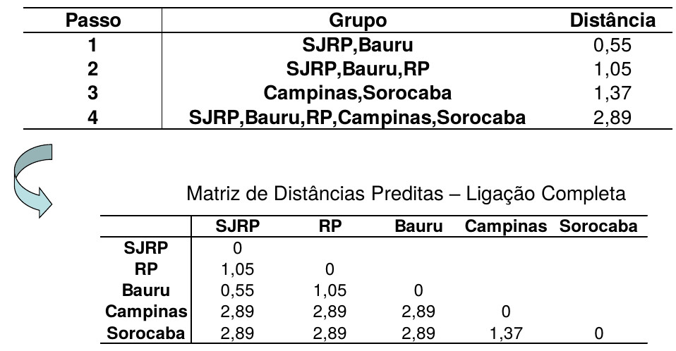

## Validação dos agrupamentos

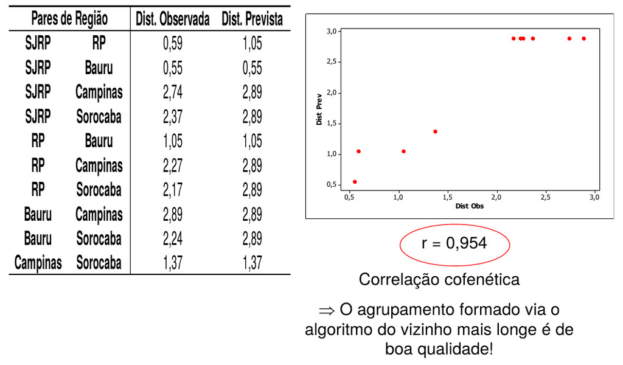

## Validação dos agrupamentos

### Correlação Cofenética

- Em um bom agrupamento, espera-se que as distâncias previstas respeitem a ordem determinada pelas distâncias observadas.
- Para avaliar a ocorrência desse comportamento, define-se a correlação cofenética como sendo a correlação entre as distâncias efetivamente observadas e as previstas.

## Validação dos agrupamentos

### Gráfico da Silhueta

- A análise (gráfico) da silhueta é um método utilizado para interpretação e validação de uma análise de clusters.
- Consiste no cálculo e representação gráfica de uma medida de quão bem cada elemento está alocado ao respectivo cluster.
- Tomando a média dessas medidas em um particular cluster, tem-se uma medida de coesão do cluster;
- Tomando-se a média dessas medidas em toda a amostra, tem-se uma medida de consistência dos agrupamentos formados.

## Validação dos agrupamentos

### Gráfico da Silhueta

- $a_{(i)}$ = distância média do objeto $i$ para os elementos de seu próprio grupo
- $b_{(i)}$ = distância média do objeto $i$ para os elementos do grupo mais próximo

$$s_{(i)} = \displaystyle{\dfrac{b_{(i)} - a_{(i)}}{\max(b_{(i)},a_{(i)})}}, \,\,\, i = 1, \cdots, n$$

- Por definição, $-1 \leqslant s_{(i)} \leqslant 1$.

## Validação dos agrupamentos

### Gráfico da Silhueta

- Se $a_{(i)} <<< b_{(i)}, s_{(i)} \approx 1$, indicando que $i$ é muito menos dissimilar dos elementos de seu grupo do que dos elementos dos outros grupos ($i$ está bem alocado);
- Se $a_{(i)} >>> b_{(i)}, s_{(i)} \approx −1$, indicando que $i$ é muito mais dissimilar dos elementos de seu grupo do que dos elementos do grupo vizinho ($i$ está mal alocado);
- Se $a_{(i)} \approx b_{(i)}, s_{(i)} \approx 0$, indicando que $i$ está na fronteira de seu grupo e do grupo vizinho.

## Validação dos agrupamentos

### Gráfico da Silhueta

| **Silhueta Média** | **Interpretação Sugerida** |
| --- | --- |
| $0{,}71 - 1{,}00$ | Grupos encontrados possuem estrutura muito robusta |
| $0{,}51 - 0{,}70$ | Grupos razoavelmente unidos |
| $0{,}26 - 0{,}50$ | A estrutura encontrada é fraca, tente outros métodos de agrupamento |
| $\leqslant 0{,}25$ | Nenhuma estrutura encontrada |

## Métodos de agrupamento não-hierárquicos - MANH

- Os MANH não se baseiam em sucessivas aglomerações (ou partições) dos elementos com base numa matiz de distâncias;
- Nos MANH tem-se a possibilidade de realocar indivíduos entre clusters ao longo do processo, diferentemente do que ocorre nos métodos hierárquicos;
- Há diferentes técnicas não hierárquicas de agrupamento, dentre as quais aquelas baseadas em partições amostrais (particularmente o algoritmo k-means) são as mais populares.

## Método k-médias (*k-means*)

1. Selecionar aleatoriamente $k$ indivíduos como centroides iniciais (ou escolha os centroides iniciais de alguma forma);
2. Calcular as distâncias entre cada indivíduo e o centro de cada um dos $k$ grupos e classificar o indivíduo no grupo mais próximo.
3. Calcule o centroide de cada grupo;
4. Repita os passos $b)$ e $c)$ até que os centroides não apresentem mais mudanças.

## Método k-médias (*k-means*)

### Esquematicamente

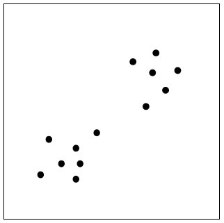